# Linear Regression

Virginia Price

8/5/2019

### Assignment:

Take the data set and use the Quiz #1 score to predict the Post Scr.

## Plot for Posterity

If we scatter plot dis bitch, we can get an idea of what the data looks like to see if a linear regression might actually make sense. basically, does it look like these things could be correlated?

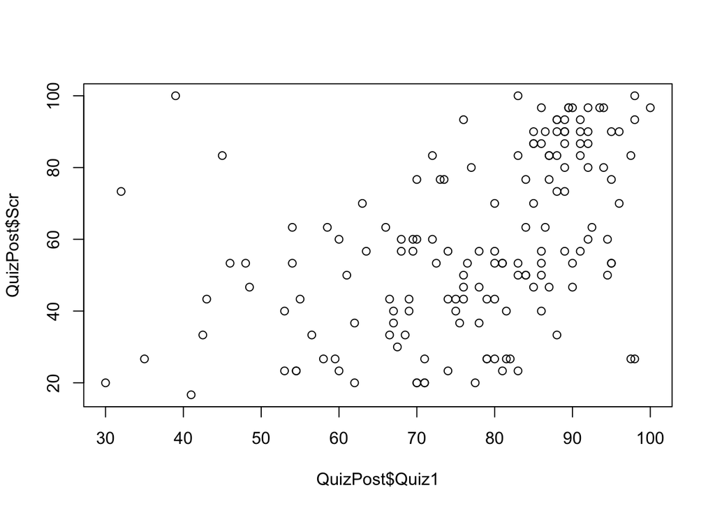

```r
plot(x=QuizPost$Quiz1, y=QuizPost$Scr)
```

So, sorta. A human eye could definitely draw an approximate line through the data, going up-ish. But we should be good scientists and actually like… quantify… that, probably.

GO R, DO YOUR STUFF

```r
linreg.q1 <- lm(formula = Scr ~ Quiz1,
             data = QuizPost)
summary(linreg.q1)
```

```
##
## Call:
## lm(formula = Scr ~ Quiz1, data = QuizPost)
##
## Residuals:
##     Min      1Q  Median      3Q     Max
## -47.134 -16.702  -1.051  18.371  69.266
##
## Coefficients:
##             Estimate Std. Error t value Pr(>|t|)
## (Intercept)   2.2668     8.9639   0.253    0.801
## Quiz1         0.7299     0.1141   6.397  1.8e-09 ***
## ---
## Signif. codes:  0 '***' 0.001 '**' 0.01 '*' 0.05 '.' 0.1 ' ' 1
##
## Residual standard error: 21.67 on 154 degrees of freedom
## Multiple R-squared:  0.2099, Adjusted R-squared:  0.2048
## F-statistic: 40.92 on 1 and 154 DF,  p-value: 1.803e-09
```

Yay, so here’s some important info:

- Reject null hypothesis that there isn’t a correlation ($p < 2 \times 10^{-9}$)
- F-statistic is also nice & big, yay
- The **coefficient of determination**, $R^2$, tells what percentage of the variance of the outcome is due to the predictor (in this case, $R^2 = 0.2099 = 21% of the variance)
- Degrees of freedom: $N-K-1 = 156-1-1 = 154$ (remember, N = observations, K = predictors)

## Checking the Model

First I’m going to do an r chunk with all of the relevant plots, then go through them one by one below.

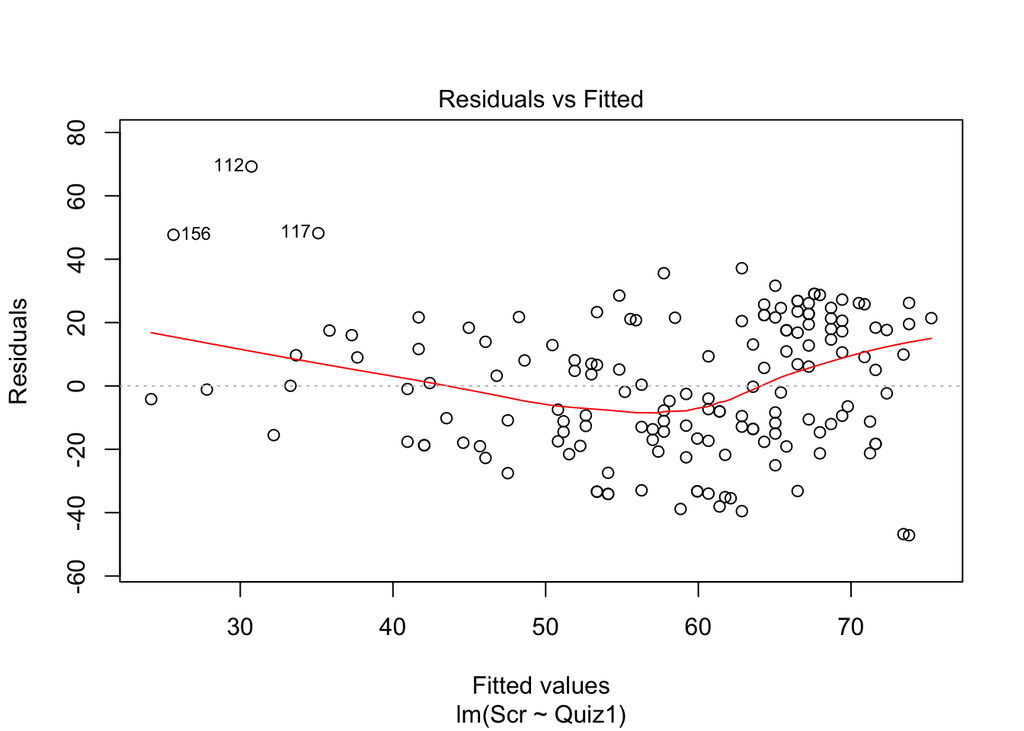

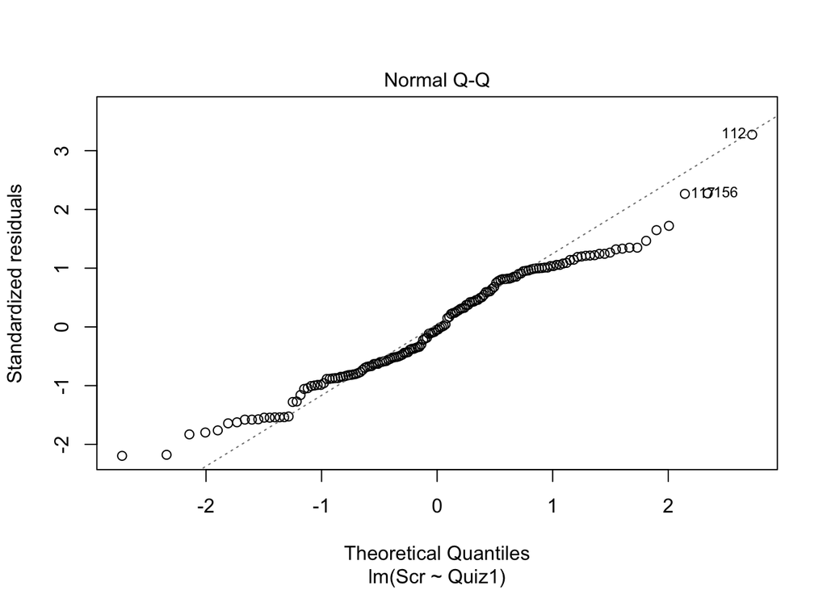

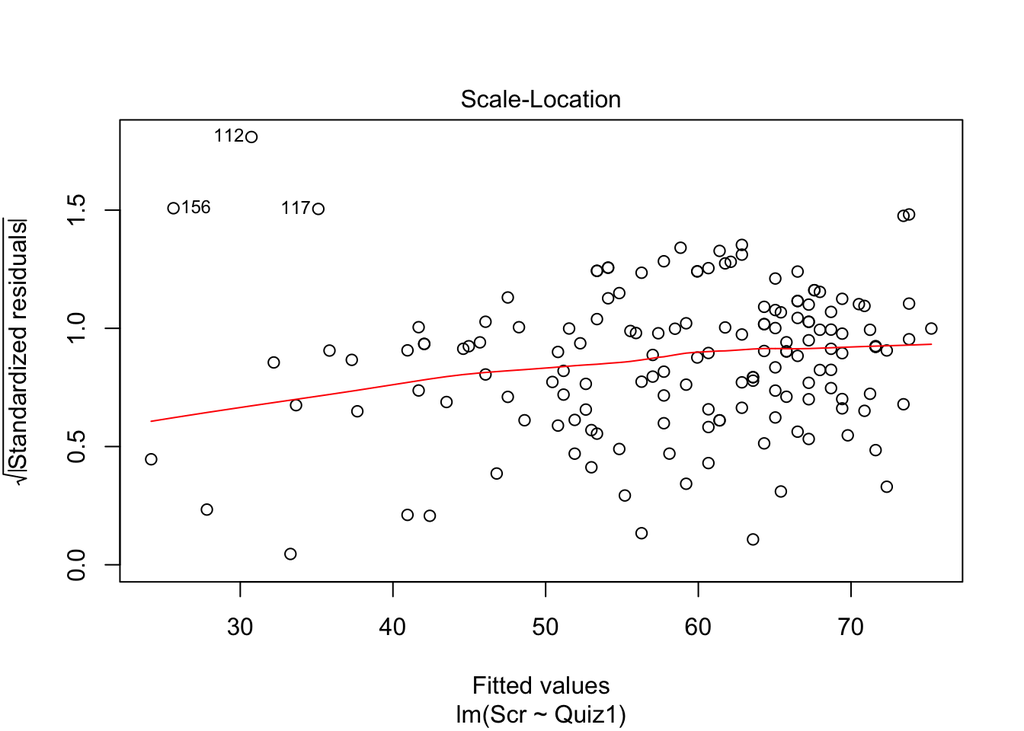

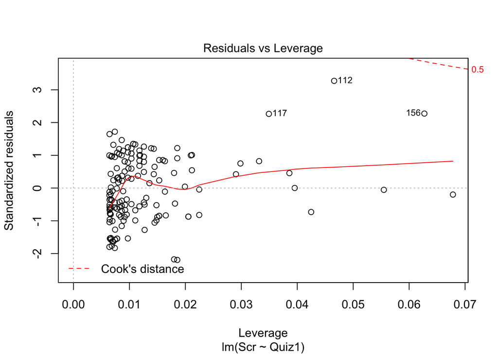

```r
plot( x = linreg.q1)
```

### Outliers

First, look at the residuals of the individual observations. Are there any extreme outliers?

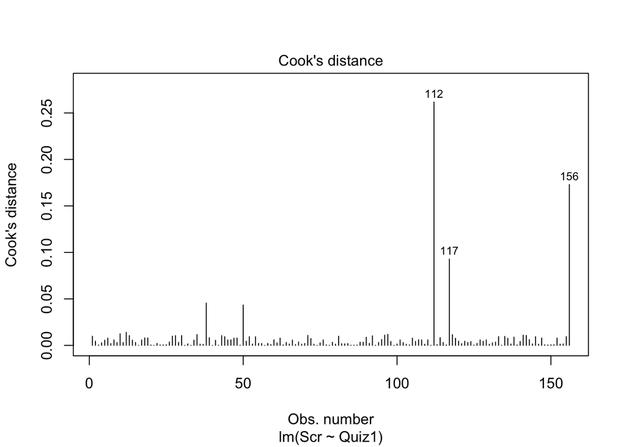

```r
plot( x = linreg.q1, which=4) # Cook's distance
```

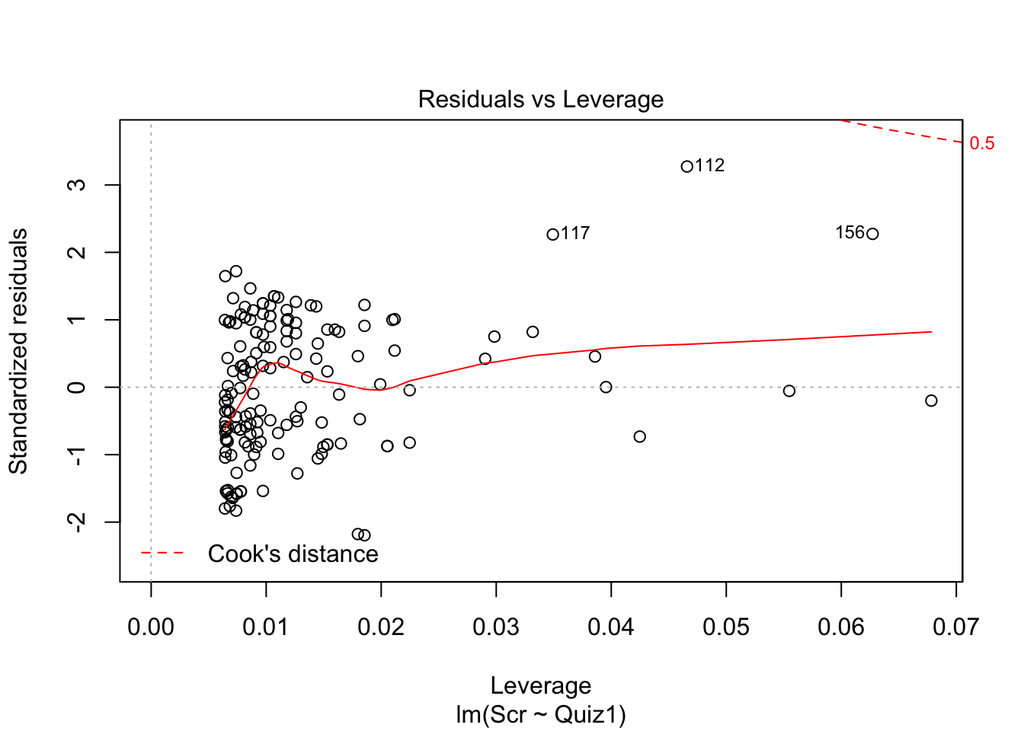

```r
plot( x = linreg.q1, which=5) # Residuals vs Leverage
```

The Cook’s distance checks the craziness of the outlier; according to Navarro, a Cook’s distance of <1 (or <4/N) tend to be okay.

The second plot’s red line shows how much the residual drifts over the trend line (which would be at the y=0 line, where the residuals would =0, right?)

### Normality of residuals

Are the residuals normally distributed? Try a couple things: a histogram, run a Shapiro-Wilk test, and qq plot

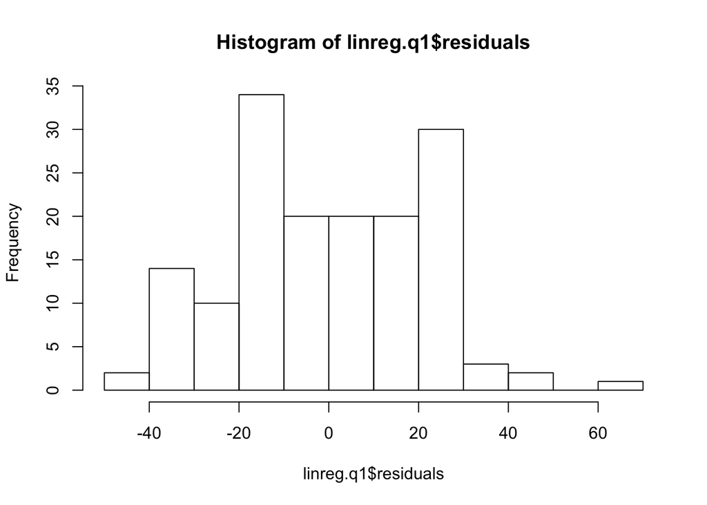

```r
hist(x = linreg.q1$residuals) # hey, not too bad actually
```

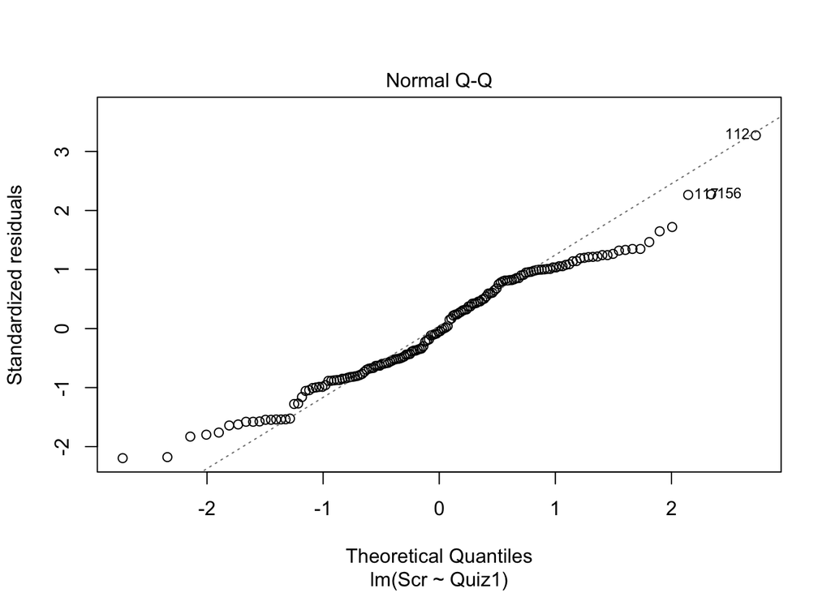

```r
plot(x = linreg.q1, which = 2)
```

```r
shapiro.test(x = linreg.q1$residuals)
```

```
##
##  Shapiro-Wilk normality test
##
## data:  linreg.q1$residuals
## W = 0.97685, p-value = 0.00997
```

The Shapiro test’s null hypothesis is that data *are* normally distributed, so if we reject the null hypothesis, that means our data *are not* normally distributed. In this case, p<0.01, so we could definitely reject the null hypothesis on this one – our data are not normally distributed :/

The histogram and qq plot also suggests a pretty non-normal distribution: it’s almost bimodal? We have some pretty heavy tails. BUUUUUT idk how to deal with this so

### Check the Linearity

This essentially tells us how “linear” out data actually is. How much does the average value deviate from the line?

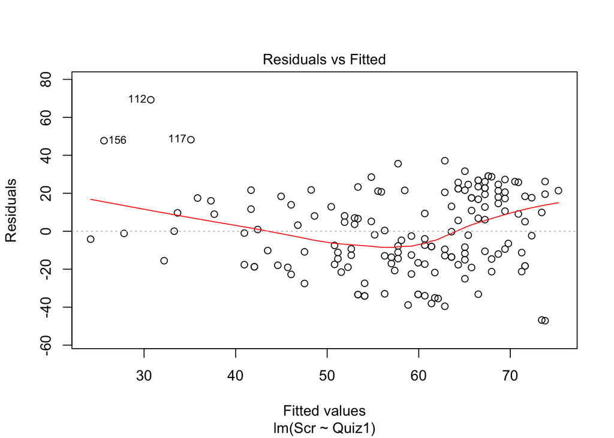

```r
plot(x = linreg.q1, which=1) # Fitted values vs residuals
```

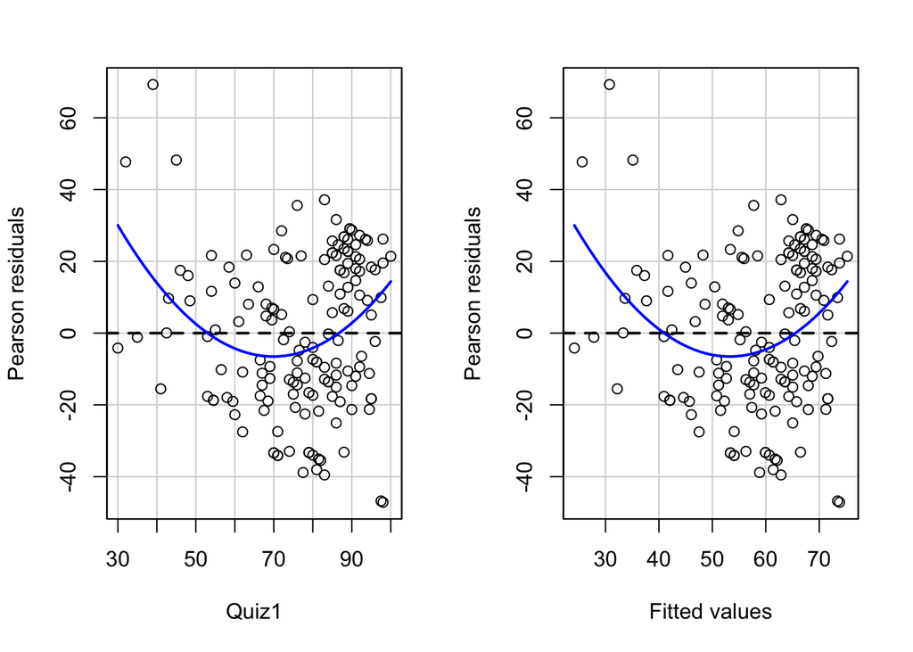

```
##            Test stat Pr(>|Test stat|)
## Quiz1         3.9388        0.0001241 ***
## Tukey test    3.9388        8.188e-05 ***
## ---
## Signif. codes:  0 '***' 0.001 '**' 0.01 '*' 0.05 '.' 0.1 ' ' 1
```

```r
residualPlots(model=linreg.q1) #fancierversion
```

Turns out deviations from the line are significant according to the t-test and Tukey Test. So this may not be a great assumption *either*; our data is sad and wiggly.

### Homogeneity of variance

How much do our residuals change over the trend line?

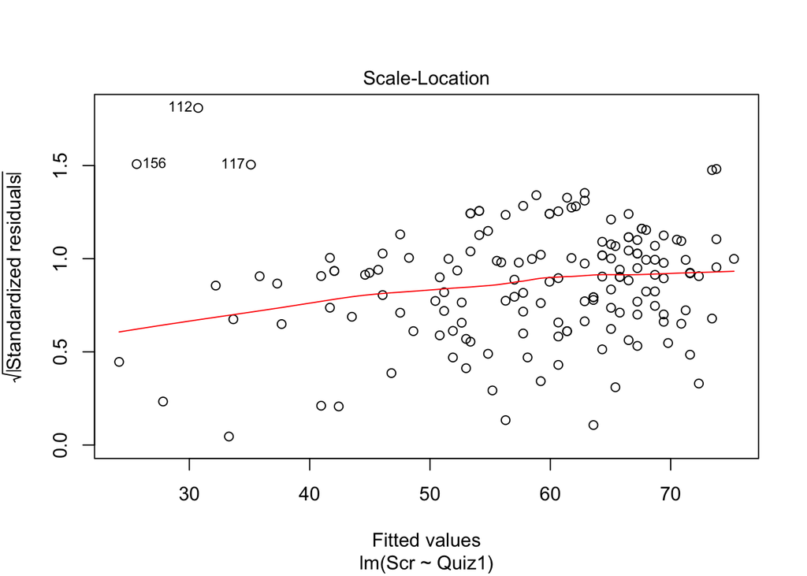

```r
plot(x = linreg.q1, which = 3)
```

```r
ncvTest(linreg.q1)
```

```
## Non-constant Variance Score Test
## Variance formula: ~ fitted.values
## Chisquare = 0.7081469, Df = 1, p = 0.40006
```

Yay! Our p-value ($p>0.05) of the non-constant variance tests implies that our variances from the trend line are pretty constant over the data set.

### Collinearity

Well, we’re only using one predictor here so this test isn’t particularly useful.

## Multiple Regression Model Possible?

How closely is Quiz 1 score related to Quiz 2 score? If they’re too related, it won’t make sense to do a multiple regression model

```r
linreg_q1a2 <- lm(formula = Quiz2 ~ Quiz1,
             data = QuizPost)
summary(linreg_q1a2)
```

```
##
## Call:
## lm(formula = Quiz2 ~ Quiz1, data = QuizPost)
##
## Residuals:
##     Min      1Q  Median      3Q     Max
## -40.544  -6.633   2.408   8.421  26.502
##
## Coefficients:
##             Estimate Std. Error t value Pr(>|t|)
## (Intercept) 12.42085    5.51322   2.253   0.0257 *
## Quiz1        0.83864    0.07018  11.950   <2e-16 ***
## ---
## Signif. codes:  0 '***' 0.001 '**' 0.01 '*' 0.05 '.' 0.1 ' ' 1
##
## Residual standard error: 13.33 on 154 degrees of freedom
## Multiple R-squared:  0.4811, Adjusted R-squared:  0.4778
## F-statistic: 142.8 on 1 and 154 DF,  p-value: < 2.2e-16
```

Okay, yeah, so maybe let’s not considering how correlated Quiz 1 is with Quiz 2.

[output not shown]